# Unsupervised Machine Learning Techniques II

### Outline

1. Introduction
   - Data Preparation
   - Basic Ratios
2. Correlation Filtering
3. Feature Engineering
   - Calculating Benchmarks
   - Calculating Deviation Measures
   - Final Feature Cleanup
4. Unsupervised Clustering
   - Setting up for K-Means clustering
   - K-Means Clustering Model
   - Using 2-component PCA to support visualization
5. Using PyOD to identify outliers
   - Setting up AutoEncoder for outlier detection
   - Building a stable AutoEncoder model using aggregation
   - Setting up an Isolation FOrest model for outlier detection
   - Builder a stable IFOrest model using max-of-max aggregation
6. Comparing AutoEncoder and Isolation Forest Models
   - Summary Statistics
   - Comparing Outlier observations

## Introduction

We continue our analysis of the healthcare provider dataset containing data on discharges, payments, coverage and medicare payments for 163,065 provider-disease group combinations.

### Data Preparation

We load and prepare the data based on previous week's findings. We perform the following steps:

- Load data
- Convert appropriate variables into float and strong types
- Rename columns to follow convention, and enable easier code blocks
- Create one additional variable for Average out of pocket payments (average_pocket_paments)

```python
#Importing packages required for data analysis and plotting
import pandas as pd
import numpy as np
import plotly
import seaborn as sns
import matplotlib.pyplot as plt
from IPython.display import display
```

```python
#Importing the data using pandas
data = pd.read_csv("icdata.csv")
```

```python
#Understanding the data
#Converting necessary columns into numeric floats
data[' Average Total Payments '] = data[' Average Total Payments '].str.extract(r'(\d+.\d)').astype('float')
data[' Average Covered Charges '] = data[' Average Covered Charges '].str.extract(r'(\d+.\d)').astype('float')
data['Average Medicare Payments'] = data['Average Medicare Payments'].str.extract(r'(\d+.\d)').astype('float')
data['Provider Id'] = data['Provider Id'].astype(str)

data.rename(columns = { "DRG Definition": "DRG_def", "Provider Id": "provider_id", "Provider Name": "provider_name", "Provider Street Address": "provider_street",
                       "Provider City": "provider_city", "Provider State": "provider_state", "Provider Zip Code": "provider_zip",
                       "Hospital Referral Region Description": "hospital_referral_region", " Total Discharges ": "total_discharges",
                       " Average Covered Charges ": "average_covered_charges", " Average Total Payments ": "average_total_payments",
                      "Average Medicare Payments": "average_medicare_payments"}, errors = "raise", inplace = True)

#Calculating out-of-pocket expenses
data['average_pocket_payments'] = data['average_total_payments'] - data['average_medicare_payments']

#data.head()
```

### Basic Ratios

Based on our preliminary resarch and the models identified in current research, we create the following ratios:

- Medicare payments to Total Payments - Typically, Medicare covers about 80% of total payments
- Medicare payments to covered charges - Ideally, average medicare payments should equal or be less than covered charges
- Total payments to covered charges
- Out-of-pocket payments to Medicare Payments

These ratios are widely used within the industry, in addition to identifying abnormallyhigh payments or number of discharges to identify fraud.

```python
#Adding additional data columns to enable factor engineering

data['medicare_by_total'] = (data['average_medicare_payments'] / data['average_total_payments'])
data['medicare_by_covered'] = (data['average_medicare_payments'] / data['average_covered_charges'])
data['total_by_covered'] = (data['average_total_payments'] / data['average_covered_charges'])
data['oop_by_medicare'] = (data['average_pocket_payments'] / data['average_medicare_payments'])
```

## Correlation Filtering

Now that we have identified provider, disease group, state, city and referral region as a factor affecting total discharges and average medicare payments. We can begin creating features that use these characterestics. However, first we need to remove variables in the current dataset which are correlated with each other.

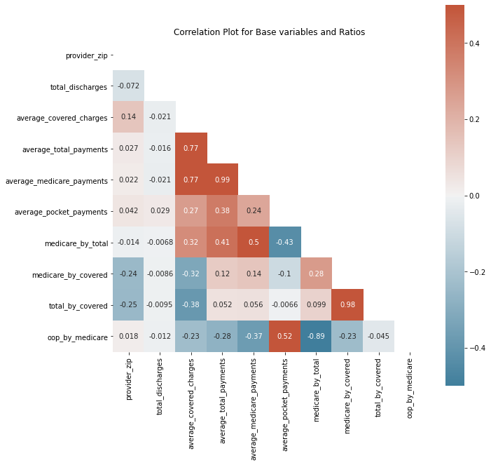

```python
corr = data.corr()
plt.figure(figsize = (10,10))
mask = np.triu(np.ones_like(corr, dtype = bool ))
cmap = sns.diverging_palette(230, 20,  as_cmap = True)
sns.heatmap(corr, mask = mask, cmap = cmap, square = True, annot= True, vmax= 0.5, vmin = -0.5, center= 0.00)
_ = plt.title('Correlation Plot for Base variables and Ratios')
```

Based on the above correlation plot, we will drop the following factors which show a high correlation (Greater than 0.7 or Less than -0.7) to one or more other factors:

- Average Total Payments (High positive correlation to Average medicare payments and Average covered charges)
- Average Covered Charges (High postive correlation to Average medicare payments)
- Ratio of Total Payments to Covered Charges (High positive correlation to ratio of medicare payments to covered charges)
- Ratio of Out of pocket payments to medicare payments (High negative correlation to ratio of medicare payments to total payments)

```python
dropvars1 = ['average_total_payments', 'average_covered_charges', 'total_by_covered', 'oop_by_medicare']
data1 = data.drop(dropvars1, axis = 1)
```

## Feature Engineering

### Calculating Benchmarks

The first step in our feature engineering journey was to create the following benchmarks for the variables associated with each observation, which we identified earlier:

- Median
- Standard Deviation

Benchmarks for were calculated for the following measures:

- Total Discharges
- Average Medicare Payments
- Average Out of Pocket Payments
- Ratio of medicare payments to covered charges
- Ratio of mediare payments to total payments

```python
##### Single level benchmark summaries for provider, city, state, and DRG
data_provider_stat1 = data1[['provider_id', 'total_discharges', 'average_pocket_payments', 'medicare_by_covered', 'average_medicare_payments',
                          'medicare_by_total']].groupby('provider_id').median()
data_provider_stat1.rename(columns = {'provider_id': 'provider_id', 'total_discharges' : 'median_provider_td', 'average_pocket_payments': 'median_provider_oop',
                                      'medicare_by_covered': 'median_provider_mbc', 'average_medicare_payments': 'median_provider_mp',
                                      'medicare_by_total': 'median_provider_mbt'}, inplace = True)

data_state_stat1 = data1[['provider_state', 'total_discharges', 'average_pocket_payments', 'medicare_by_covered', 'average_medicare_payments',
                          'medicare_by_total']].groupby('provider_state').median()
data_state_stat1.rename(columns = {'provider_state': 'provider_state', 'total_discharges' : 'median_state_td', 'average_pocket_payments': 'median_state_oop',
                                      'medicare_by_covered': 'median_state_mbc', 'average_medicare_payments': 'median_state_mp',
                                      'medicare_by_total': 'median_state_mbt'}, inplace = True)

data_city_stat1 = data1[['provider_city', 'total_discharges', 'average_pocket_payments', 'medicare_by_covered', 'average_medicare_payments',
                          'medicare_by_total']].groupby('provider_city').median()
data_city_stat1.rename(columns = {'provider_city': 'provider_city', 'total_discharges' : 'median_city_td', 'average_pocket_payments': 'median_city_oop',
                                      'medicare_by_covered': 'median_city_mbc', 'average_medicare_payments': 'median_city_mp',
                                      'medicare_by_total': 'median_city_mbt'}, inplace = True)

data_drg_stat1 = data1[['DRG_def', 'total_discharges', 'average_pocket_payments', 'medicare_by_covered', 'average_medicare_payments',
                          'medicare_by_total']].groupby('DRG_def').median()
data_drg_stat1.rename(columns = {'DRG_def': 'DRG_def', 'total_discharges' : 'median_drg_td', 'average_pocket_payments': 'median_drg_oop',
                                      'medicare_by_covered': 'median_drg_mbc', 'average_medicare_payments': 'median_drg_mp',
                                      'medicare_by_total': 'median_drg_mbt'}, inplace = True)


data_provider_stat2 = data1[['provider_id', 'total_discharges', 'average_pocket_payments', 'medicare_by_covered', 'average_medicare_payments',
                          'medicare_by_total']].groupby('provider_id').std()
data_provider_stat2.rename(columns = {'provider_id': 'provider_id', 'total_discharges' : 'sd_provider_td', 'average_pocket_payments': 'sd_provider_oop',
                                      'medicare_by_covered': 'sd_provider_mbc', 'average_medicare_payments': 'sd_provider_mp',
                                      'medicare_by_total': 'sd_provider_mbt'}, inplace = True)

data_state_stat2 = data1[['provider_state', 'total_discharges', 'average_pocket_payments', 'medicare_by_covered', 'average_medicare_payments',
                          'medicare_by_total']].groupby('provider_state').std()
data_state_stat2.rename(columns = {'provider_state': 'provider_state', 'total_discharges' : 'sd_state_td', 'average_pocket_payments': 'sd_state_oop',
                                      'medicare_by_covered': 'sd_state_mbc', 'average_medicare_payments': 'sd_state_mp',
                                      'medicare_by_total': 'sd_state_mbt'}, inplace = True)

data_city_stat2 = data1[['provider_city', 'total_discharges', 'average_pocket_payments', 'medicare_by_covered', 'average_medicare_payments',
                          'medicare_by_total']].groupby('provider_city').std()
data_city_stat2.rename(columns = {'provider_city': 'provider_city', 'total_discharges' : 'sd_city_td', 'average_pocket_payments': 'sd_city_oop',
                                      'medicare_by_covered': 'sd_city_mbc', 'average_medicare_payments': 'sd_city_mp',
                                      'medicare_by_total': 'sd_city_mbt'}, inplace = True)

data_drg_stat2 = data1[['DRG_def', 'total_discharges', 'average_pocket_payments', 'medicare_by_covered', 'average_medicare_payments',
                          'medicare_by_total']].groupby('DRG_def').std()
data_drg_stat2.rename(columns = {'DRG_def': 'DRG_def', 'total_discharges' : 'sd_drg_td', 'average_pocket_payments': 'sd_drg_oop',
                                      'medicare_by_covered': 'sd_drg_mbc', 'average_medicare_payments': 'sd_drg_mp',
                                      'medicare_by_total': 'sd_drg_mbt'}, inplace = True)

#data_provider_stat1.head()
```

We followed a simple naming convention for the benchmarks created.

- sd_drg_mbc : Standard deviation for Medicare payments by Covered Charges for each DRG

And so on.

```python
###### DUAL Level summary benchmarks for DRG and State

data_drg_state_stat1 = data1[['DRG_def', 'provider_state', 'total_discharges', 'average_medicare_payments', 'average_pocket_payments', 'medicare_by_covered', 'medicare_by_total'
                          ]].groupby(['DRG_def', 'provider_state']).median()
data_drg_state_stat1.rename(columns = {'DRG_def': 'DRG_def', 'provider_state': 'provider_state', 'total_discharges' : 'median_drg_state_td', 'average_pocket_payments': 'median_drg_state_oop',
                                      'medicare_by_covered': 'median_drg_state_mbc', 'average_medicare_payments': 'median_drg_state_mp',
                                      'medicare_by_total': 'median_drg_state_mbt'}, inplace = True)

data_drg_state_stat2 = data1[['DRG_def', 'provider_state', 'total_discharges', 'average_medicare_payments', 'average_pocket_payments', 'medicare_by_covered', 'medicare_by_total'
                          ]].groupby(['DRG_def', 'provider_state']).std()
data_drg_state_stat2.rename(columns = {'DRG_def': 'DRG_def', 'provider_state': 'provider_state', 'total_discharges' : 'sd_drg_state_td', 'average_pocket_payments': 'sd_drg_state_oop',
                                      'medicare_by_covered': 'sd_drg_state_mbc', 'average_medicare_payments': 'sd_drg_state_mp',
                                      'medicare_by_total': 'sd_drg_state_mbt'}, inplace = True)

###### DUAL Level summary benchmarks for DRG and Referral Region

data_drg_rfg_stat1 = data1[['DRG_def', 'hospital_referral_region','total_discharges', 'average_medicare_payments', 'average_pocket_payments', 'medicare_by_covered', 'medicare_by_total'
                           ]].groupby(['DRG_def', 'hospital_referral_region']).median()
data_drg_rfg_stat1.rename(columns = {'DRG_def': 'DRG_def', 'hospital_referral_region': 'hospital_referral_region', 'total_discharges' : 'median_drg_rfg_td', 'average_pocket_payments': 'median_drg_rfg_oop',
                                      'medicare_by_covered': 'median_drg_rfg_mbc', 'average_medicare_payments': 'median_drg_rfg_mp',
                                      'medicare_by_total': 'median_drg_rfg_mbt'}, inplace = True)

data_drg_rfg_stat2 = data1[['DRG_def', 'hospital_referral_region','total_discharges', 'average_medicare_payments', 'average_pocket_payments', 'medicare_by_covered', 'medicare_by_total'
                           ]].groupby(['DRG_def', 'hospital_referral_region']).std()
data_drg_rfg_stat2.rename(columns = {'DRG_def': 'DRG_def', 'hospital_referral_region': 'hospital_referral_region', 'total_discharges' : 'sd_drg_rfg_td', 'average_pocket_payments': 'sd_drg_rfg_oop',
                                      'medicare_by_covered': 'sd_drg_rfg_mbc', 'average_medicare_payments': 'sd_drg_rfg_mp',
                                      'medicare_by_total': 'sd_drg_rfg_mbt'}, inplace = True)

#data_drg_rfg_stat2.head()
```

In this manner, we have summary statistics across the following aggregations:

- Single level
  - Provider
  - State
  - City
  - Disease group
- Dual level
  - Disease group and State
  - Disease group and referral group

Each of these aggregations will serve as a benchmark for us to calculate deviation from. For example, single level aggregations will show us what the mean and Standard deviation for each provider, city, state and disease group is. From this we can calculate deviations for observation in that specific provider, city, state and DRG. Similarly, dual level aggregations will give us more granular benchmarks.

### Calculating Deviation Measures

We left-join the benchmark statistics to our dataframe to enable calculation of deviation measures

```python
####### Combining with the main data frame

### Base level combination
data1 = data1.merge(data_provider_stat1, on = 'provider_id', how = 'left')
data1 = data1.merge(data_provider_stat2, on = 'provider_id', how = 'left')

data1 = data1.merge(data_state_stat1, on = 'provider_state', how = 'left')
data1 = data1.merge(data_state_stat2, on = 'provider_state', how = 'left')

data1 = data1.merge(data_city_stat1, on = 'provider_city', how = 'left')
data1 = data1.merge(data_city_stat2, on = 'provider_city', how = 'left')

data1 = data1.merge(data_drg_stat1, on = 'DRG_def', how = 'left')
data1 = data1.merge(data_drg_stat2, on = 'DRG_def', how = 'left')

#level 1 - drg X state
data1 = pd.merge(data1, data_drg_state_stat1, left_on = ['DRG_def', 'provider_state'], right_on = ['DRG_def', 'provider_state'])
data1 = pd.merge(data1, data_drg_state_stat2, left_on = ['DRG_def', 'provider_state'], right_on = ['DRG_def', 'provider_state'])

#level 1 - drg X referral group
data1 = pd.merge(data1, data_drg_rfg_stat1, left_on = ['DRG_def', 'hospital_referral_region'], right_on = ['DRG_def', 'hospital_referral_region'])
data1 = pd.merge(data1, data_drg_rfg_stat2, left_on = ['DRG_def', 'hospital_referral_region'], right_on = ['DRG_def', 'hospital_referral_region'])
```

This deviation, similar to a Z-score, can be calculated at the level of each aggregation identified previously. The naming convention followed is straightforward:

All deviation measures start with dev_ followed by the aggregation level (provider or state or DRG and so on) and end with the variable name (td or mp or mbc and so on). For example,

- dev_provider_td : Deviation of total discharge from the benchmark for this provider
- dev_DRG_mbc : Deviation of the ratio of medicare payments to covered charges for this specific DRG

```python
#Creating deviation measures ( abs(value - mean)/std deviation)
#deviation measure for provider mean and drg and state median
data1['dev_provider_oop'] = (data1['average_pocket_payments'] - data1['median_provider_oop'])/data1['sd_provider_oop']
data1['dev_provider_mbc'] = (data1['medicare_by_covered'] - data1['median_provider_mbc'])/data1['sd_provider_mbc']
data1['dev_provider_mp'] = (data1['average_medicare_payments'] - data1['median_provider_mp'])/data1['sd_provider_mp']
data1['dev_provider_td'] = (data1['total_discharges'] - data1['median_provider_td'])/data1['sd_provider_td']
data1['dev_provider_mbt']= (data1['medicare_by_total'] - data1['median_provider_mbt']) / data1['sd_provider_mbt']

data1['dev_state_oop'] = (data1['average_pocket_payments'] - data1['median_state_oop'])/data1['sd_state_oop']
data1['dev_state_mbc'] = (data1['medicare_by_covered'] - data1['median_state_mbc'])/data1['sd_state_mbc']
data1['dev_state_mp'] = (data1['average_medicare_payments'] - data1['median_state_mp'])/data1['sd_state_mp']
data1['dev_state_td'] = (data1['total_discharges'] - data1['median_state_td'])/data1['sd_state_td']
data1['dev_state_mbt']= (data1['medicare_by_total'] - data1['median_state_mbt']) / data1['sd_state_mbt']

data1['dev_city_oop'] = (data1['average_pocket_payments'] - data1['median_city_oop'])/data1['sd_city_oop']
data1['dev_city_mbc'] = (data1['medicare_by_covered'] - data1['median_city_mbc'])/data1['sd_city_mbc']
data1['dev_city_mp'] = (data1['average_medicare_payments'] - data1['median_city_mp'])/data1['sd_city_mp']
data1['dev_city_td'] = (data1['total_discharges'] - data1['median_city_td'])/data1['sd_city_td']
data1['dev_city_mbt']= (data1['medicare_by_total'] - data1['median_city_mbt']) / data1['sd_city_mbt']

data1['dev_drg_oop'] = (data1['average_pocket_payments'] - data1['median_drg_oop'])/data1['sd_drg_oop']
data1['dev_drg_mbc'] = (data1['medicare_by_covered'] - data1['median_drg_mbc'])/data1['sd_drg_mbc']
data1['dev_drg_mp'] = (data1['average_medicare_payments'] - data1['median_drg_mp'])/data1['sd_drg_mp']
data1['dev_drg_td'] = (data1['total_discharges'] - data1['median_drg_td'])/data1['sd_drg_td']
data1['dev_drg_mbt']= (data1['medicare_by_total'] - data1['median_drg_mbt']) / data1['sd_drg_mbt']

#deviation measure for drg and state
data1['dev_drg_state_oop'] = (data1['average_pocket_payments'] - data1['median_drg_state_oop'])/data1['sd_drg_state_oop']
data1['dev_drg_state_mbc'] = (data1['medicare_by_covered'] - data1['median_drg_state_mbc'])/data1['sd_drg_state_mbc']
data1['dev_drg_state_mp'] = (data1['average_medicare_payments'] - data1['median_drg_state_mp'])/data1['sd_drg_state_mp']
data1['dev_drg_state_td'] = (data1['total_discharges'] - data1['median_drg_state_td'])/data1['sd_drg_state_td']
data1['dev_drg_state_mbt']= (data1['medicare_by_total'] - data1['median_drg_state_mbt']) / data1['sd_drg_state_mbt']

#deviation measure for drg and hospital referral group
data1['dev_drg_rfg_oop'] = (data1['average_pocket_payments'] - data1['median_drg_rfg_oop'])/data1['sd_drg_rfg_oop']
data1['dev_drg_rfg_mbc'] = (data1['medicare_by_covered'] - data1['median_drg_rfg_mbc'])/data1['sd_drg_rfg_mbc']
data1['dev_drg_rfg_mp'] = (data1['average_medicare_payments'] - data1['median_drg_rfg_mp'])/data1['sd_drg_rfg_mp']
data1['dev_drg_rfg_td'] = (data1['total_discharges'] - data1['median_drg_rfg_td'])/data1['sd_drg_rfg_td']
data1['dev_drg_rfg_mbt']= (data1['medicare_by_total'] - data1['median_drg_rfg_mbt']) / data1['sd_drg_rfg_mbt']
```

### Final Feature Clean-up

Next, we clean up the engineered features and prepare for modelling. We perform the following steps:

- Remove all benchmark variables from the dataset
- Replace all missing values, NaNs and InF with mean values
- Use one hot encoding to convert categorical variables into numerical variables
- Check for correlation
- Remove highly correlated variables

```python
#Cleanin up data for modelling by removing factors and null values
drop_vars = data1.iloc[:, 13:73].columns.tolist()
#Creating index of columns with null values
null_col = data1.isnull().sum().sort_values(ascending = False)
null_col = null_col[ null_col > 0]
#Looping through to replace NAs with mean values
null_col = null_col.index
for col in null_col:
  data1.loc[:, col].fillna(data1.loc[:, col].mean(), inplace = True)
```

```python
#Recategorizing variables to enable one hot encoding
drg_levels = data1['DRG_def'].value_counts().nlargest(25).index.tolist()
data1['new_drg'] = data1['DRG_def'].apply(lambda x: x if x in drg_levels else 'other')
hrr_levels = data1['hospital_referral_region'].value_counts(normalize = True).nlargest(25).index.tolist()
data1['new_hrr'] = data1['hospital_referral_region'].apply(lambda x: x if x in hrr_levels else 'other')
state_levels = data1['provider_state'].value_counts(normalize = True).nlargest(25).index.tolist()
data1['new_state'] = data1['provider_state'].apply(lambda x: x if x in state_levels else 'other')
pid_levels = data1['provider_id'].value_counts(normalize = True).nlargest(25).index.tolist()
data1['new_pid'] = data1['provider_id'].apply(lambda x: x if x in pid_levels else 'other')
```

```python
dummy_drg = pd.get_dummies(data1['new_drg'], dummy_na=False, drop_first= True)
dummy_state = pd.get_dummies(data1['new_state'], dummy_na=False, drop_first= True)
dummy_hrr = pd.get_dummies(data1['new_hrr'], dummy_na=False, drop_first= True)
dummy_pid = pd.get_dummies(data1['new_pid'], dummy_na=False, drop_first= True)
```

```python
#preparing the data
#Copying data into new df
data_model = data1.copy()
data_model = pd.concat([data_model, dummy_drg], axis = 1)
data_model = pd.concat([data_model, dummy_state], axis = 1)
data_model = pd.concat([data_model, dummy_hrr], axis = 1)
data_model = pd.concat([data_model, dummy_pid], axis = 1)
#Removing factor data
drop_cols = ['DRG_def', 'provider_id', 'provider_name', 'provider_street', 'provider_city', 'provider_state', 'provider_zip', 'hospital_referral_region', 'new_hrr', 'new_drg', 'new_state', 'new_pid']
data_model = data_model.drop(drop_cols, axis = 1)
data_model = data_model.drop(drop_vars, axis = 1)
#data_model.info()
```

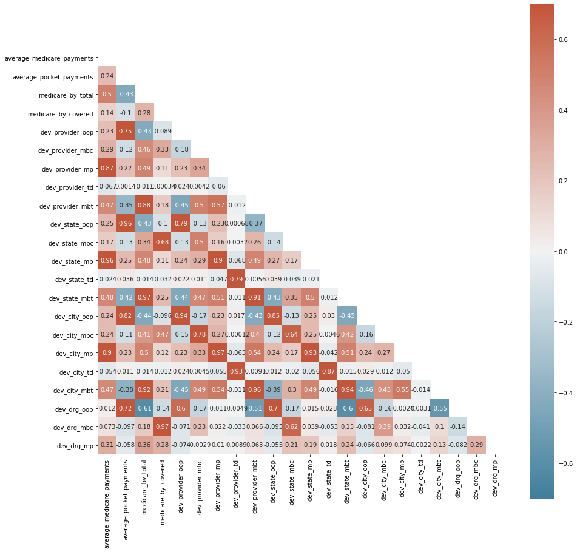

```python
#Checking for correlation
newdata = data_model.iloc[:, 1:23]
ncorr = newdata.corr()
plt.figure(figsize = (15, 15))
mask = np.triu(np.ones_like(ncorr, dtype = bool ))
cmap = sns.diverging_palette(230, 20,  as_cmap = True)
_ = sns.heatmap(ncorr, mask = mask, cmap = cmap, square = True, annot= True, vmax= 0.7, vmin = -0.7, center= 0.00)
```

```python
#dropping highly correlated variables
dropvars2 = ['dev_city_mp', 'dev_city_mbt', 'dev_drg_oop', 'dev_drg_mbc', 'dev_drg_mbt', 'dev_drg_state_mp', 'dev_drg_state_td', 'dev_drg_state_oop', 'dev_drg_rfg_mbc', 'dev_drg_rfg_oop', 'dev_drg_rfg_td', 'dev_drg_rfg_mbt']
data_model = data_model.drop(dropvars2, axis = 1)
```

This leaves us with the following factors for clustering:

- 7 Base features: DRG, State, Provider, Hospital Referral Group, Total discharges, Average medicare payments, Averge out of pocket payments
- 2 Ratios: Medicare payments to covered charges, medicare payments to total payments
- 18 deviation measures

## Unsupervised Clustering

Before we use pyOD to identify outliers, we will attempt to cluster these observations on the basis of the available data. This serves two purposes:

1. Reducing the number of observations which need to be examined manually
2. Provide a model for identifying differences between outliers identified by the models

### Setting Up for K-Means Clustering

For K-means clustering, we perform the following steps:

- Scale and standardize the numerical data using scikit learn

```python
#Loading required packages
from sklearn.cluster import KMeans
from sklearn.preprocessing import StandardScaler
```

```python
#Standardizing all values
scaler = StandardScaler()
data_model = scaler.fit_transform(data_model)
```

### K-Means Clustering Model with 8 Clusters

Based on our explorations in previous weeks, we model with 8 clusters and use these clusters

```python
#Building a 8 cluster model
kmm = KMeans(n_clusters = 8, random_state= 250)
kmm.fit(data_model)
```

```
KMeans(random_state=250)
```

```python
#adding the labels to the dataset
data_check = data.copy()
#data_check = data_check.drop(drop_vars, axis = 1)
data_check['label'] = kmm.labels_
```

```python
print("Percentage of observation in each cluster")
data_check['label'].value_counts(normalize = True) * 100
```

```
Percentage of observation in each cluster
```

```
2    38.266949
3    37.876307
4     9.167510
7     4.818937
1     4.487168
0     3.150891
5     1.201361
6     1.030877
Name: label, dtype: float64
```

```python
#adding the labels to the dataset
data_check2 = data1.copy()
data_check2 = data_check2.drop(drop_vars, axis = 1)
data_check2['label'] = kmm.labels_

#summarizing values by label
display(data_check2[['total_discharges', 'average_medicare_payments', 'medicare_by_total', 'medicare_by_covered', 'dev_drg_mp', 'dev_drg_mbc', 'label', 'dev_drg_td', 'dev_drg_mbt', 'dev_city_td']].groupby('label').median().sort_values(by = 'average_medicare_payments', ascending = False))
```

| label | total_discharges | average_medicare_payments | medicare_by_total | medicare_by_covered | dev_drg_mp | dev_drg_mbc | dev_drg_td | dev_drg_mbt | dev_city_td |
| --- | --- | --- | --- | --- | --- | --- | --- | --- | --- |
| 1 | 22 | 12629.50 | 0.756879 | 0.214202 | -0.198831 | -0.246840 | -0.132665 | -2.126048 | -0.142368 |
| 3 | 22 | 9106.20 | 0.916411 | 0.288677 | 0.141754 | 0.165972 | -0.153192 | 0.210825 | -0.090883 |
| 7 | 33 | 8338.25 | 0.900934 | 0.669923 | 1.418056 | 2.565727 | 0.328508 | 0.508459 | 0.000000 |
| 4 | 119 | 6361.70 | 0.856523 | 0.243248 | 0.026045 | -0.116802 | 1.194832 | -0.104807 | 2.146488 |
| 0 | 32 | 6219.20 | 0.872564 | 0.355154 | 0.185731 | 0.692034 | 0.286315 | 0.149450 | 0.000000 |
| 6 | 26 | 5573.20 | 0.841836 | 0.270280 | -0.237122 | 0.124356 | -0.114901 | -0.165885 | -0.016678 |
| 5 | 32 | 5240.10 | 0.841771 | 0.175734 | -0.378815 | -0.449448 | 0.220281 | -0.241671 | 0.000000 |
| 2 | 26 | 4084.00 | 0.797978 | 0.203331 | -0.159952 | -0.198264 | -0.051939 | -0.307528 | 0.000000 |

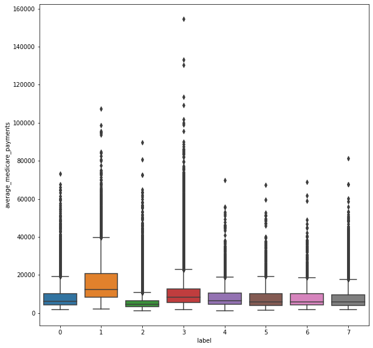

```python
plt.figure(figsize = (10,10))
_ = sns.boxplot(data = data_check, x = 'label', y = 'average_medicare_payments', palette = 'tab10')
```

### Principal Component Analysis

We use a 2 component PCA to visually estimate how divergent the different clusters are. We performed the following steps:

- Prepared the model and tags
- Setup a 2-factor PCA model

```python
#Attempting PCA analysis
x = data_model.copy()
y = kmm.labels_
```

```python
from sklearn. decomposition import PCA
pca = PCA(n_components = 2)

principalComponents = pca.fit_transform(x)
principalDf = pd.DataFrame(data = principalComponents
             , columns = ['principal component 1', 'principal component 2'])
finalDf = pd.concat([principalDf, data_check['label']], axis = 1)
```

## Anomaly detection with PyOD methods

Let us now extend the analysis further using the following PyOD methods:

- AutoEncoder
- Isolation Forests

### Using AutoEncoder for identifying Outliers

The AutoEncoder class in pyOD is a neural network with hidden layers with fewer nodes than the input or output nodes. This forces the activation functions to reduce the dimensionality of the dataset, thereby reducing noise and as a consequence, idntifying outliers. While PCA reduces dimensionality in a linear manner, with AutoEncoder we have a variey of functions to use.

For effective tuning, the following paramaters need to changed in AutoEncoder:

1. Number of hidden layers and number of nodes in each hidden layer.
2. Number of epochs, where the default is 100 epochs.
3. The activation function (Input/Output and/or hidden layer), default is Relu (Rectified Linear Unit) for hidden and sigmoidal function for ouput.

Steps for Preparing the model:

- Similar to PCA and KNN we need to standardize the input data
- For the base mode, we used 4 hidden layers with 27, 2, 2, and 27 nodes respectively, and all other paramters set on default.
- We added the decision scores to the dataframe and analysed their distribution
- We used a threshold of 14.5 to label outliers.

```python
#import required package
from pyod.models.auto_encoder import AutoEncoder
```

```python
#attempting model 1 with following nodes [27, 2, 2, 27]
model_ae1 = AutoEncoder(hidden_neurons = [27, 2, 2, 27], verbose = 0, random_state = 250)
_ = model_ae1.fit(data_model)
```

```python
#checking decision scores
data_check['score_ae1'] = model_ae1.decision_scores_
```

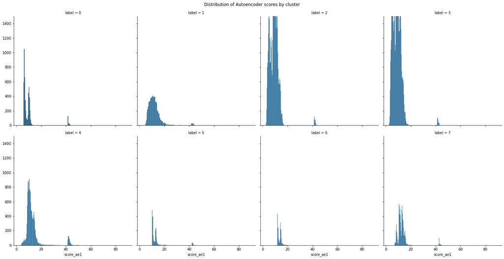

```python
#histogram by cluster
_ = plt.figure(figsize = (18, 12))
h = sns.FacetGrid(data = data_check, col = 'label', col_wrap = 4, height = 5, ylim = (0, 1500))
_ = h.map(sns.histplot, 'score_ae1', bins = 'auto')
_ = plt.suptitle("Distribution of Autoencoder scores by cluster", y = 1.02, fontsize = 12)
```

As can be seen from the histograms, A large proportion of the observations lie below 15. After a few rounds of experimenting, we used 14.5 as our cut-off.

```python
#using threshold of 14.5
data_check['label_ae1'] = data_check['score_ae1'].apply(lambda x : 1 if x >= 14.5 else 0)

#checking summary statistics
print("Number of outliers:\n")
display(data_check['label_ae1'].value_counts())
display(data_check.groupby('label_ae1').mean().iloc[:, 0:11])
```

```
Number of outliers:
```

```
0    153292
1      9773
Name: label_ae1, dtype: int64
```

| label_ae1 | provider_zip | total_discharges | average_covered_charges | average_total_payments | average_medicare_payments | average_pocket_payments | medicare_by_total | medicare_by_covered | total_by_covered | oop_by_medicare | label |
| --- | --- | --- | --- | --- | --- | --- | --- | --- | --- | --- | --- |
| 0 | 47906.781535 | 41.917295 | 35749.268760 | 9571.605490 | 8367.868032 | 1203.737457 | 0.846403 | 0.284157 | 0.333954 | 0.197153 | 2.736601 |
| 1 | 48429.703673 | 56.250077 | 42167.162427 | 11837.947549 | 10479.923299 | 1358.024250 | 0.848748 | 0.298873 | 0.349549 | 0.194997 | 3.334698 |

Using the specified cut-off identified 9773 outliers, which is ~6% of the observations. As can be seen from the summary table above, the outliers are significantly higher than the typical observations in number of discharges, average covered charges, average medicare payments and average pocket payments!

### Building a stable model by aggregation

However, the autoencoder model is sensitive to the initial randmoization and can provide different results with the same parameter tunings. Therefore to build a more stable model, we built multiple AutoEncoder models with different parameters as listed below:

```python
#Attempting new models with multiple neural networks
#attempting model 2 with following nodes [27, 13, 6, 2, 2, 6, 13, 27]
model_ae2 = AutoEncoder(hidden_neurons = [27, 13, 6, 2, 2, 6, 13, 27], verbose = 0, random_state = 250)
model_ae2.fit(data_model)

#checking decision scores
data_check['score_ae2'] = model_ae2.decision_scores_
```

```python
#Attempting new models with multiple neural networks
#attempting model 3 with following nodes [20, 10, 5, 2, 2, 5, 10, 20] with 200 epochs
model_ae3 = AutoEncoder(hidden_neurons = [20, 10, 2, 2, 10, 20], verbose = 0, random_state = 250, epochs = 200)
model_ae3.fit(data_model)

#checking decision scores
data_check['score_ae3'] = model_ae3.decision_scores_
```

```python
#Attempting new models with multiple neural networks and different activation and deacivation functions
#attempting model 4 with following nodes [27, 10, 2, 2, 10, 27]
model_ae4 = AutoEncoder(hidden_neurons = [27, 10, 2, 2, 10, 27], verbose = 0, random_state = 250, hidden_activation = 'selu')
model_ae4.fit(data_model)

#checking decision scores
data_check['score_ae4'] = model_ae4.decision_scores_
```

Surprisingly, almost all models had a similar performance. Varying the number of layers or nodes, epochs or activation function, did not change the performance drastically.

```python
%%capture [--no-stderr]
#standardizing anomaly scores from AutoEncoder

from pyod.models.combination import aom, moa, average, maximization

# Put all the predictions in a data frame
ae_scores = pd.DataFrame({
    'model1' : data_check['score_ae1'],
    'model2' : data_check['score_ae2'],
    'model3' : data_check['score_ae3'],
    'model4' : data_check['score_ae4']
})

ae_scores_norm = StandardScaler().fit_transform(ae_scores)
data_check['avg_ae_score'] = average(ae_scores_norm)
```

We averaged the scores between all models and examined the histogram to be able to identify the threshold value

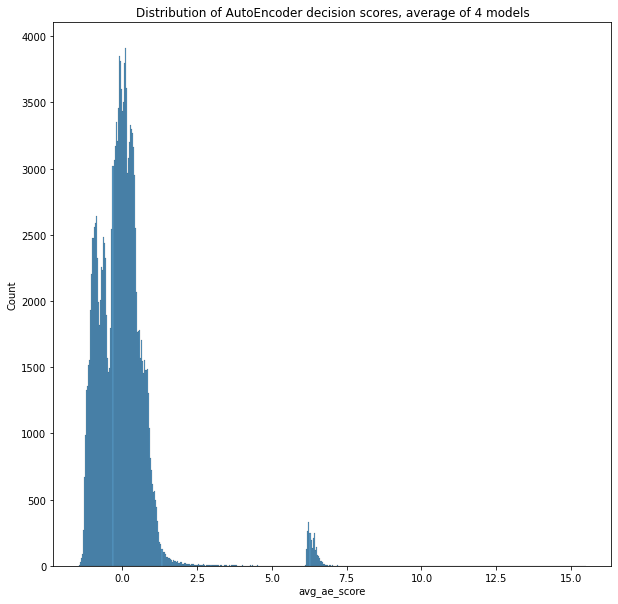

```python
plt.figure(figsize = (10,10))
sns.histplot(data = data_check, x = 'avg_ae_score', bins = 'auto')
_ = plt.title('Distribution of AutoEncoder decision scores, average of 4 models')
```

Based on the histogram and a few trails, we picked 0.9 as the threshold value.

```python
#using threshold of 14.5
data_check['label_ae'] = data_check['avg_ae_score'].apply(lambda x : 1 if x >= 0.9 else 0)

#checking summary statistics
print("Number of outliers:\n")
display(data_check['label_ae'].value_counts())
display(data_check.groupby('label_ae').mean().iloc[:, 0:11])
```

```
Number of outliers:
```

```
0    152904
1     10161
Name: label_ae, dtype: int64
```

| label_ae | provider_zip | total_discharges | average_covered_charges | average_total_payments | average_medicare_payments | average_pocket_payments | medicare_by_total | medicare_by_covered | total_by_covered | oop_by_medicare | label |
| --- | --- | --- | --- | --- | --- | --- | --- | --- | --- | --- | --- |
| 0 | 47904.181709 | 41.874281 | 35754.918778 | 9570.893937 | 8367.124871 | 1203.769066 | 0.846417 | 0.284120 | 0.333905 | 0.197142 | 2.734637 |
| 1 | 48448.858282 | 56.350064 | 41837.071578 | 11762.114319 | 10410.457189 | 1351.657130 | 0.848440 | 0.298876 | 0.349688 | 0.195244 | 3.341403 |

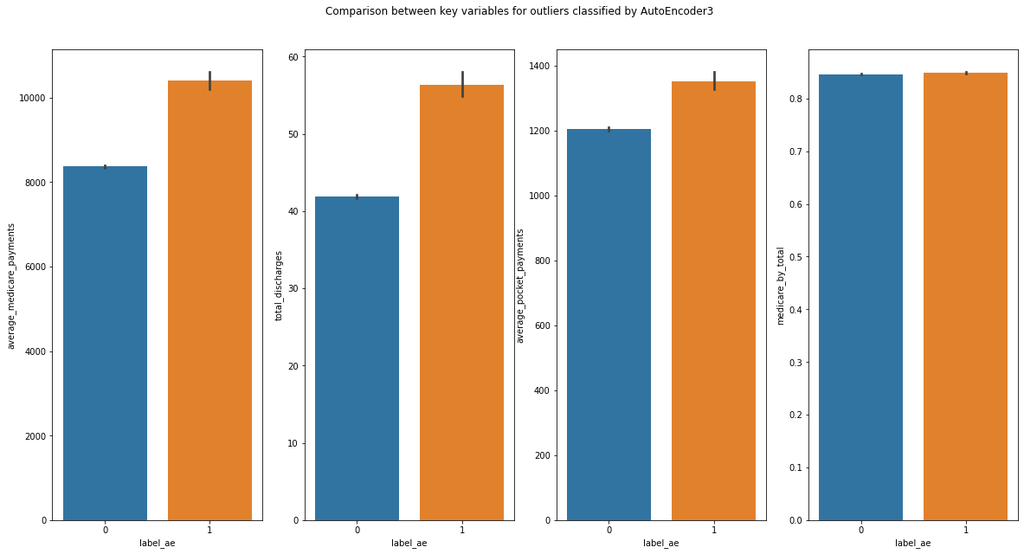

```python
#visualizing differences
fig, axs = plt.subplots(ncols = 4, nrows = 1, figsize = (20,10))
sns.barplot(x = 'label_ae', y = 'average_medicare_payments', data = data_check, ax = axs[0])
sns.barplot(x = 'label_ae', y = 'total_discharges', data = data_check, ax = axs[1])
sns.barplot(x = 'label_ae', y = 'average_pocket_payments', data = data_check, ax = axs[2])
sns.barplot(x = 'label_ae', y = 'medicare_by_total', data = data_check, ax = axs[3])
_ = fig.suptitle("Comparison between key variables for outliers classified by AutoEncoder3", y = 0.95, fontsize = 12)
```

### Setting up an Isolation Forest for Outlier Detection

The Isolation Forest is a tree-based method which is significantly different from the neural-network based AutoEncoder method. The isolation forest algorithm builds a tree such that the outliers are identified first and the deeper into the tree, the more normal and typical the observations is.

In order to tune the IForest model, we need to vary the number of max_samples.

In our base model, we use 100 max_samples.

```python
#Importing required packages for iforest
from pyod.models.iforest import IForest
```

[figure not shown]

```python
#Building a IForest model with 100 samples
model_if1 = IForest(behaviour="new", max_samples=100, verbose = 0, random_state = 250)
model_if1.fit(data_model)

#checking decision scores
data_check['score_if1'] = model_if1.decision_scores_

#histogram by cluster
plt.figure(figsize = (18, 12))
h = sns.FacetGrid(data = data_check, col = 'label', col_wrap = 4, height = 5, ylim = (0, 1500))
h.map(sns.histplot, 'score_if1', bins = 'auto')
_ = plt.suptitle("Distribution of Autoencoder 4 scores by cluster", y = 1.02)
```

```python
#using threshold of 0
data_check['label_if1'] = data_check['score_if1'].apply(lambda x : 1 if x >= 0 else 0)

#checking summary statistics
print("Number of outliers:\n")
display(data_check['label_if1'].value_counts())
display(data_check.groupby('label_if1').mean().iloc[:, 0:11])
```

```
Number of outliers:
```

```
0    146758
1     16307
Name: label_if1, dtype: int64
```

| label_if1 | provider_zip | total_discharges | average_covered_charges | average_total_payments | average_medicare_payments | average_pocket_payments | medicare_by_total | medicare_by_covered | total_by_covered | oop_by_medicare | label |
| --- | --- | --- | --- | --- | --- | --- | --- | --- | --- | --- | --- |
| 0 | 47920.382289 | 41.445339 | 34932.121933 | 9350.805804 | 8168.179023 | 1182.626782 | 0.846023 | 0.284441 | 0.334402 | 0.197520 | 2.737268 |
| 1 | 48097.773042 | 54.754584 | 46949.667903 | 12916.983621 | 11430.790446 | 1486.193175 | 0.851225 | 0.290423 | 0.339269 | 0.192552 | 3.089042 |

### Building a stable model by max-of-max aggregation

```python
#Building a IForest model with 250 samples
model_if2 = IForest(behaviour="new", max_samples=250, verbose = 0, random_state = 250)
model_if2.fit(data_model)

#checking decision scores
data_check['score_if2'] = model_if2.decision_scores_
```

```python
#Building a IForest model with 60 samples
model_if3 = IForest(behaviour="new", max_samples=60, verbose = 0, random_state = 250)
model_if3.fit(data_model)

#checking decision scores
data_check['score_if3'] = model_if3.decision_scores_
```

[figure not shown]

```python
#standardizing anomaly scores IForest

#from pyod.models.combination import aom, moa, average, maximization

# Put all the predictions in a data frame
if_scores = pd.DataFrame({
    'model1' : data_check['score_if1'],
    'model2' : data_check['score_if2'],
    'model3' : data_check['score_if3']
})

if_scores_norm = StandardScaler().fit_transform(ae_scores)
data_check['max_if_score'] = maximization(ae_scores_norm)

#Plotting histogram
plt.figure(figsize = (10,10))
sns.histplot(data = data_check, x = 'max_if_score', bins = 'auto')
_ = plt.title('Distribution of Isolation Forest decision scores, average of 4 models', y = 1.02, fontsize = 12)
```

```python
#using threshold of 0
data_check['label_if'] = data_check['max_if_score'].apply(lambda x : 1 if x >= 0.9 else 0)

#checking summary statistics
print("Number of outliers:\n")
display(data_check['label_if'].value_counts())
display(data_check.groupby('label_if').mean().iloc[:, 0:10])
```

```
Number of outliers:
```

```
0    152904
1     10161
Name: label_if, dtype: int64
```

| label_if | provider_zip | total_discharges | average_covered_charges | average_total_payments | average_medicare_payments | average_pocket_payments | medicare_by_total | medicare_by_covered | total_by_covered | oop_by_medicare |
| --- | --- | --- | --- | --- | --- | --- | --- | --- | --- | --- |
| 0 | 47904.181709 | 41.874281 | 35754.918778 | 9570.893937 | 8367.124871 | 1203.769066 | 0.846417 | 0.284120 | 0.333905 | 0.197142 |
| 1 | 48448.858282 | 56.350064 | 41837.071578 | 11762.114319 | 10410.457189 | 1351.657130 | 0.848440 | 0.298876 | 0.349688 | 0.195244 |

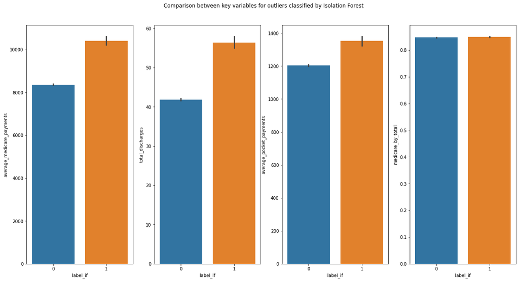

```python
#visualizing differences
fig, axs = plt.subplots(ncols = 4, nrows = 1, figsize = (20,10))
sns.barplot(x = 'label_if', y = 'average_medicare_payments', data = data_check, ax = axs[0])
sns.barplot(x = 'label_if', y = 'total_discharges', data = data_check, ax = axs[1])
sns.barplot(x = 'label_if', y = 'average_pocket_payments', data = data_check, ax = axs[2])
sns.barplot(x = 'label_if', y = 'medicare_by_total', data = data_check, ax = axs[3])
_ = fig.suptitle("Comparison between key variables for outliers classified by Isolation Forest", y = 0.95, fontsize = 12)
```

## Comparing IForest with AutoEncoder Model

Finally, we compare the IForest Model and the AutoENcoder Model on deviation measures.

```python
data_check2['label_if'] = data_check['label_if']
data_check2['label_ae'] = data_check['label_ae']
```

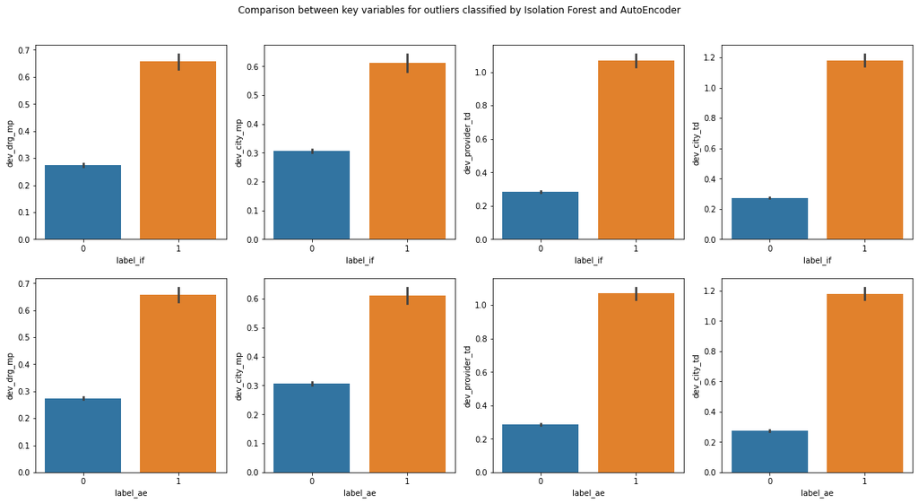

```python
#dev_drg_mp, dev_city_mp, dev_city_td, dev_provider_td
#visualizing differences
fig, axs = plt.subplots(ncols = 4, nrows = 2, figsize = (20,10))
sns.barplot(x = 'label_if', y = 'dev_drg_mp', data = data_check2, ax = axs[0, 0])
sns.barplot(x = 'label_if', y = 'dev_city_mp', data = data_check2, ax = axs[0, 1])
sns.barplot(x = 'label_if', y = 'dev_provider_td', data = data_check2, ax = axs[0, 2])
sns.barplot(x = 'label_if', y = 'dev_city_td', data = data_check2, ax = axs[0, 3])
sns.barplot(x = 'label_ae', y = 'dev_drg_mp', data = data_check2, ax = axs[1, 0])
sns.barplot(x = 'label_ae', y = 'dev_city_mp', data = data_check2, ax = axs[1, 1])
sns.barplot(x = 'label_ae', y = 'dev_provider_td', data = data_check2, ax = axs[1, 2])
sns.barplot(x = 'label_ae', y = 'dev_city_td', data = data_check2, ax = axs[1, 3])
_ = fig.suptitle("Comparison between key variables for outliers classified by Isolation Forest and AutoEncoder", y = 0.95, fontsize = 12)
```

As can be seen, when we look at summary statistics both AutoEncoder and IForest, have performed to a similar level. The measures are equally high for outliers identified from both models.

### Comparing outliers

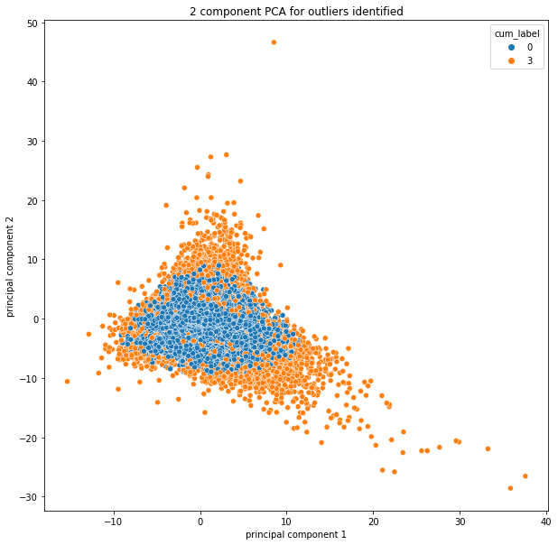

```python
#PCA based visualisation
finalDf['cum_label'] = (2 * data_check['label_ae']) + (data_check['label_if'])

plt.figure(figsize = (10,10))
sns.color_palette('tab10')
sns.scatterplot(x = 'principal component 1', y = 'principal component 2', hue = 'cum_label', data = finalDf, palette='tab10')
_ = plt.title("2 component PCA for outliers identified", loc = 'center')
```